# Project BIOL 3100

Noah Christensen

## **[Home](http://Noahjc26.github.io/index.html)** | **[About Me](http://Noahjc26.github.io/about_me/index.html)** | **[Final Project](http://Noahjc26.github.io/final_project/index.html)**

Geologic maps serve as a valuable tool in resource exploration. Traditional mapping is characterized by time-intensive and high-cost fieldwork, but through multispectral and hyperspectral remotely sensed images it is possible to map extensive areas instantly.

# **Background**

## FWHM

Full Width Half Mass (FWHM) is an important concept for understanding how different band values are calculated.

The graph below visualizes the idea of FWHM. Each band in a spectral device only takes in a specific range of wavelengths, often the wavelength for each band is just denoted as the peak, but in reality each sensor is collecting a range of wavelengths. This is determined by denoting the FWHM as the area between the 50% transmittance on either side of the curve.

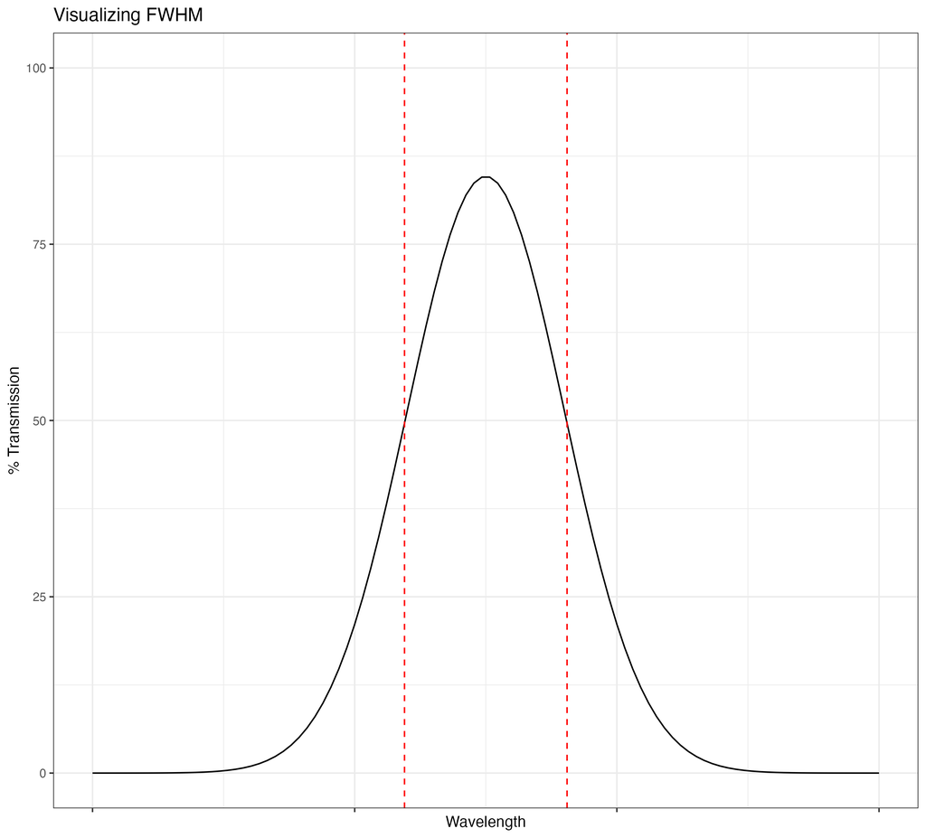

In this plot you can see all the bands for Landsat 8, Hyperion, and ASTER. With their FWHM denoted as boxes. Its important to point out how Landsat 8 does have a band in the Short Wave Infrared (SWIR), but the FWHM is wide and this means that any SWIR data saved for this band could be attributed to any wavelength inside of the FWHM.

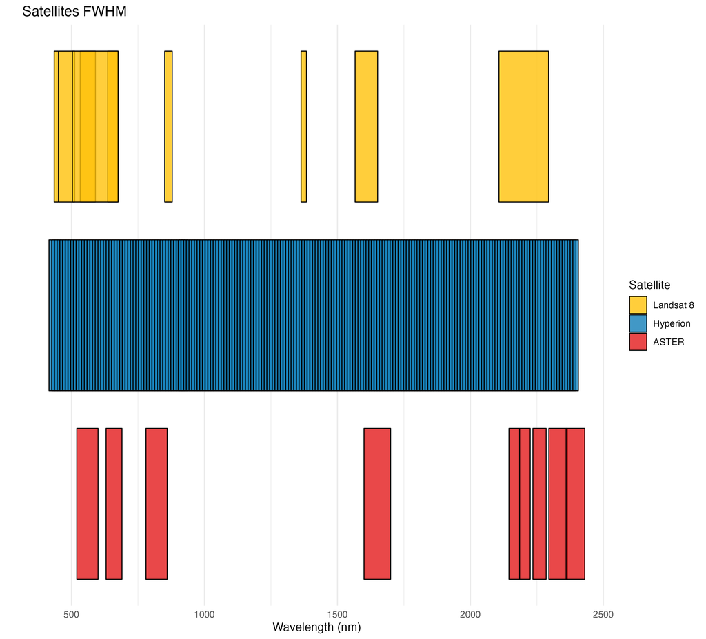

# **HYPERION**

Hyperion data was downloaded from the **[USGS EARTH EXPLORER](https://earthexplorer.usgs.gov/)** as an *L1T Product in GeoTiff format*

Reading in L1T product

```r
l <- list.files(path="../../Hyperion/sevier_lake/EO1H0380332014325110PZ_1T/",
                pattern='TIF$',
                full.names=TRUE)
```

Rasterizing only working bands with the terra package

```r
r <- rast(l[c(8:57,77:224)])
```

## Hyperion Information

**[HYPERION BAND INFORMATION](https://developers.google.com/earth-engine/datasets/catalog/EO1_HYPERION#bands)**

| Satellite_Name | Bands | Wavelength_Units | Wavelength_nm | FWHM_nm | Description | Irradiance | Irradiance_Units | Rad_Conv |
| --- | --- | --- | --- | --- | --- | --- | --- | --- |
| Hyperion | B008 | W/m^2 SRμm | 426.82 | 11.3871 | VNIR | 1650.52 | W/m^2-mu | 40 |
| Hyperion | B009 | W/m^2 SRμm | 436.99 | 11.3871 | VNIR | 1714.90 | W/m^2-mu | 40 |
| Hyperion | B010 | W/m^2 SRμm | 447.17 | 11.3871 | VNIR | 1994.52 | W/m^2-mu | 40 |
| Hyperion | B011 | W/m^2 SRμm | 457.34 | 11.3871 | VNIR | 2034.72 | W/m^2-mu | 40 |
| Hyperion | B012 | W/m^2 SRμm | 467.52 | 11.3871 | VNIR | 1970.12 | W/m^2-mu | 40 |
| Hyperion | B013 | W/m^2 SRμm | 477.69 | 11.3871 | VNIR | 2036.22 | W/m^2-mu | 40 |
| Hyperion | B014 | W/m^2 SRμm | 487.87 | 11.3784 | VNIR | 1860.24 | W/m^2-mu | 40 |
| Hyperion | B015 | W/m^2 SRμm | 498.04 | 11.3538 | VNIR | 1953.29 | W/m^2-mu | 40 |
| Hyperion | B016 | W/m^2 SRμm | 508.22 | 11.3133 | VNIR | 1953.55 | W/m^2-mu | 40 |
| Hyperion | B017 | W/m^2 SRμm | 518.39 | 11.2580 | VNIR | 1804.56 | W/m^2-mu | 40 |
| Hyperion | B018 | W/m^2 SRμm | 528.57 | 11.1907 | VNIR | 1905.51 | W/m^2-mu | 40 |
| Hyperion | B019 | W/m^2 SRμm | 538.74 | 11.1119 | VNIR | 1877.50 | W/m^2-mu | 40 |
| Hyperion | B020 | W/m^2 SRμm | 548.92 | 11.0245 | VNIR | 1883.51 | W/m^2-mu | 40 |
| Hyperion | B021 | W/m^2 SRμm | 559.09 | 10.9321 | VNIR | 1821.99 | W/m^2-mu | 40 |
| Hyperion | B022 | W/m^2 SRμm | 569.27 | 10.8368 | VNIR | 1841.92 | W/m^2-mu | 40 |
| Hyperion | B023 | W/m^2 SRμm | 579.45 | 10.7407 | VNIR | 1847.51 | W/m^2-mu | 40 |
| Hyperion | B024 | W/m^2 SRμm | 589.62 | 10.6482 | VNIR | 1779.99 | W/m^2-mu | 40 |
| Hyperion | B025 | W/m^2 SRμm | 599.80 | 10.5607 | VNIR | 1761.45 | W/m^2-mu | 40 |
| Hyperion | B026 | W/m^2 SRμm | 609.97 | 10.4823 | VNIR | 1740.80 | W/m^2-mu | 40 |
| Hyperion | B027 | W/m^2 SRμm | 620.15 | 10.4147 | VNIR | 1708.88 | W/m^2-mu | 40 |
| Hyperion | B028 | W/m^2 SRμm | 630.32 | 10.3595 | VNIR | 1672.09 | W/m^2-mu | 40 |
| Hyperion | B029 | W/m^2 SRμm | 640.50 | 10.3188 | VNIR | 1632.83 | W/m^2-mu | 40 |
| Hyperion | B030 | W/m^2 SRμm | 650.67 | 10.2942 | VNIR | 1591.92 | W/m^2-mu | 40 |
| Hyperion | B031 | W/m^2 SRμm | 660.85 | 10.2856 | VNIR | 1557.66 | W/m^2-mu | 40 |
| Hyperion | B032 | W/m^2 SRμm | 671.02 | 10.2980 | VNIR | 1525.41 | W/m^2-mu | 40 |
| Hyperion | B033 | W/m^2 SRμm | 681.20 | 10.3349 | VNIR | 1470.93 | W/m^2-mu | 40 |
| Hyperion | B034 | W/m^2 SRμm | 691.37 | 10.3909 | VNIR | 1450.37 | W/m^2-mu | 40 |
| Hyperion | B035 | W/m^2 SRμm | 701.55 | 10.4592 | VNIR | 1393.18 | W/m^2-mu | 40 |
| Hyperion | B036 | W/m^2 SRμm | 711.72 | 10.5322 | VNIR | 1372.75 | W/m^2-mu | 40 |
| Hyperion | B037 | W/m^2 SRμm | 721.90 | 10.6004 | VNIR | 1235.63 | W/m^2-mu | 40 |

[output cut: 168 more lines]

## Correcting Imagery

When downloading Hyperion imagery it is stored with DN values. Using information from the metadata you can correct this to surface reflectance.

```r
md <- read_lines("../../Hyperion/sevier_lake/EO1H0380332014325110PZ_1T/EO1H0380332014325110PZ_MTL_L1T.TXT")

julian_day <- as.numeric(word(md[18], 8))     #julian day
d <- (1-0.01672*cos(0.9865*(julian_day-4)))   #earth sun distance in astronomical distance
sun_elevation <- as.numeric(word(md[300],7))  #sun elevation
s <- (90-sun_elevation)                       #solar zenith angle in degrees
```

Equation to correct Hyperion DN values into surface reflectance values

```r
#correcting to surface reflectance
Surf_Reflectance = (pi*(r/Hyperion_Bands$Rad_Conv)*d^2)/(cos(s*pi/180)*Hyperion_Bands$Irradiance)
```

Now we can plot using three bands to create an RGB image

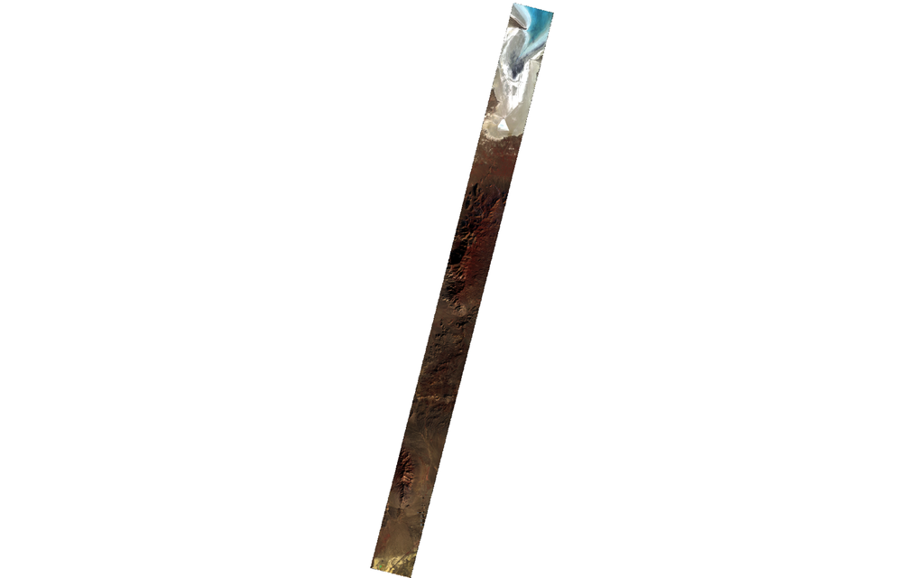

```r
Surf_Reflectance %>%
  plotRGB(r=31,g=20,b=10,stretch = "lin")
```

## Spectral Library

Inserting spectral library from **[USGS](https://crustal.usgs.gov/speclab/QueryAll07a.php)**

Here’s all the minerals in the USGS spectral library for Hyperion:

| acmite | actinolite | adularia | albite | allanite | almandine | alunite |
| --- | --- | --- | --- | --- | --- | --- |
| ammonio | amphibole | analcime | ancylite | andalusite | andesine | andradite |
| anhydrite | annite | anorthite | anthophyllite | antigorite | aragonite | arsenopyrite |
| augite | axinite | azurite | barite | bassanite | bastnaesite | beidellite |
| beryl | biotite | bloedite | bronzite | brookite | brucite | buddingtonite |
| butlerite | bytownite | calcite | carbon | carnallite | cassiterite | celestite |
| chalcedony | chalcopyrite | chert | chlorapatite | chlorite | chromite | chrysocolla |
| chrysotile | cinnabar | clinochlore | clinoptilolite | clintonite | colemanite | cookeite |
| copiapite | coquimbite | corrensite | corundum | cronstedtite | cummingtonite | cuprite |
| datolite | diaspore | dickite | diopside | dipyre | dolomite | dumortierite |
| elbaite | endellite | enstatite | epidote | epsomite | eugsterite | fassaite |
| ferrihydrite | fluorapatite | forsterite | galena | gaylussite | gibbsite | glauconite |
| glaucophane | goethite | grossular | gypsum | halite | halloysite | hectorite |
| hedenbergite | hematite | heulandite | hornblende | howlite | hydrogrossular | hydroxyl |
| hypersthene | illite | ilmenite | jadeite | jarosite | kainite | kaolinite |
| karpatite | kieserite | knebelite | labradorite | laumontite | lazurite | lepidocrocite |
| lepidolite | limonite | lizardite | maghemite | magnetite | malachite | margarite |
| marialite | mascagnite | meionite | microcline | mirabilite | mizzonite | monazite |
| monticellite | montmorillonite | mordenite | muscovite | nacrite | nanohematite | natrolite |
| nepheline | nephrite | niter | nontronite | oligoclase | olivine | opal |
| orthoclase | palygorskite | paragonite | parisite | pectolite | perthite | phlogopite |
| pigeonite | pinnoite | pitch | polyhalite | portlandite | prehnite | prochlorite |
| psilomelane | pyrite | pyrolusite | pyromorphite | pyrophyllite | pyroxene | pyroxmangite |
| pyrrhotite | quartz | rectorite | rhodochrosite | rhodonite | richterite | riebeckite |
| rivadavite | roscoelite | rutile | sanidine | saponite | sauconite | schwertmannite |
| scolecite | sepiolite | serpentine | siderite | siderophyllite | smaragdite | sodium |
| spessartine | sphalerite | sphene | spodumene | staurolite | stilbite | strontianite |
| sulfur | syngenite | talc | thenardite | thuringite | tincalconite | topaz |
| tourmaline | tremolite | trona | ulexite | uralite | uvarovite | vermiculite |
| vesuvianite | witherite | wollastonite | xenotime | zircon | zoisite | zunyite |

That’s a lot of minerals